# taitanic

```python
import pandas as pd
import numpy as np
import matplotlib.pyplot as plt
import seaborn as sns
plt.style.use('fivethirtyeight')
import warnings
warnings.filterwarnings('ignore')
%matplotlib inline
from sklearn.discriminant_analysis import LinearDiscriminantAnalysis
sns.set(font_scale=2)
```

```python
df=pd.read_csv('train.csv')
df
```

|  | PassengerId | Survived | Pclass | Name | Sex | Age | SibSp | Parch | Ticket | Fare | Cabin | Embarked |
| --- | --- | --- | --- | --- | --- | --- | --- | --- | --- | --- | --- | --- |
| 0 | 1 | 0 | 3 | Braund, Mr. Owen Harris | male | 22.0 | 1 | 0 | A/5 21171 | 7.2500 | NaN | S |
| 1 | 2 | 1 | 1 | Cumings, Mrs. John Bradley (Florence Briggs Th... | female | 38.0 | 1 | 0 | PC 17599 | 71.2833 | C85 | C |
| 2 | 3 | 1 | 3 | Heikkinen, Miss. Laina | female | 26.0 | 0 | 0 | STON/O2. 3101282 | 7.9250 | NaN | S |
| 3 | 4 | 1 | 1 | Futrelle, Mrs. Jacques Heath (Lily May Peel) | female | 35.0 | 1 | 0 | 113803 | 53.1000 | C123 | S |
| 4 | 5 | 0 | 3 | Allen, Mr. William Henry | male | 35.0 | 0 | 0 | 373450 | 8.0500 | NaN | S |
| ... | ... | ... | ... | ... | ... | ... | ... | ... | ... | ... | ... | ... |
| 886 | 887 | 0 | 2 | Montvila, Rev. Juozas | male | 27.0 | 0 | 0 | 211536 | 13.0000 | NaN | S |
| 887 | 888 | 1 | 1 | Graham, Miss. Margaret Edith | female | 19.0 | 0 | 0 | 112053 | 30.0000 | B42 | S |
| 888 | 889 | 0 | 3 | Johnston, Miss. Catherine Helen "Carrie" | female | NaN | 1 | 2 | W./C. 6607 | 23.4500 | NaN | S |
| 889 | 890 | 1 | 1 | Behr, Mr. Karl Howell | male | 26.0 | 0 | 0 | 111369 | 30.0000 | C148 | C |
| 890 | 891 | 0 | 3 | Dooley, Mr. Patrick | male | 32.0 | 0 | 0 | 370376 | 7.7500 | NaN | Q |

891 rows × 12 columns

Checking out where the Null Values are inorder to fix them later in my code

```python
df.isnull().sum()
```

```
PassengerId      0
Survived         0
Pclass           0
Name             0
Sex              0
Age            177
SibSp            0
Parch            0
Ticket           0
Fare             0
Cabin          687
Embarked         2
dtype: int64
```

First of all let us check what percentage survived and what percentage died will plot them into a pie chart as percentages and into a barchart as numbers

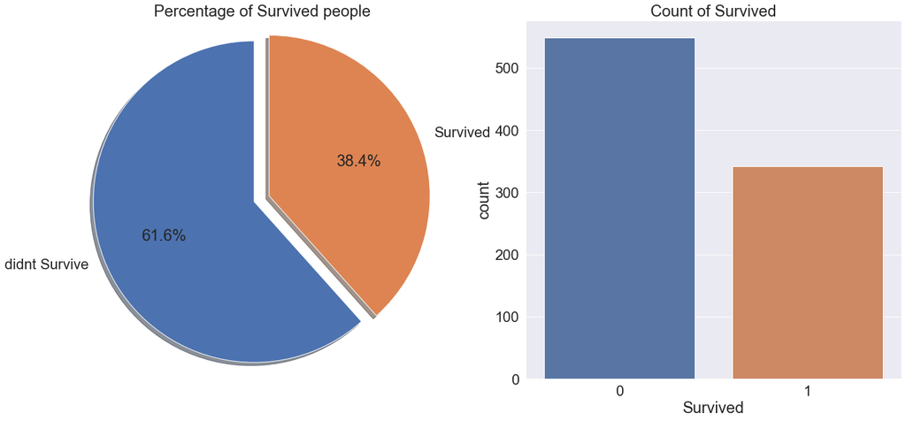

```python
labels= 'didnt Survive','Survived'
sizes=df['Survived'].value_counts()
explode = (0, 0.1)  # only "explode" the 2nd slice (i.e. 'Hogs')



fig, ax = plt.subplots(1,2,figsize=(20,10))
ax[0].set_title('Percentage of Survived people')
ax[0].pie(sizes, explode=explode, labels=labels, autopct='%1.1f%%',
        shadow=True, startangle=90)
ax[0].axis('equal')  # Equal aspect ratio ensures that pie is drawn as a circle.



ax[1].set_title('Count of Survived')

sns.countplot('Survived',data=df,ax=ax[1])


plt.show()
```

Based on the Pie Chart the percentage of people who Survived the is 38.4% which is a small Percentage

The next step is to go one by one over the features and check the correlation between the survival and the features The next feature we are gonna go through is Sex

```python
df.groupby(['Sex','Survived'])['Survived'].count()
```

```
Sex     Survived
female  0            81
        1           233
male    0           468
        1           109
Name: Survived, dtype: int64
```

```python
df[['Sex','Survived']].groupby(['Sex']).mean()
```

| Sex | Survived |
| --- | --- |
| female | 0.742038 |
| male | 0.188908 |

we are gonna plot these into a bar chart to better visualize the percentages and numbers

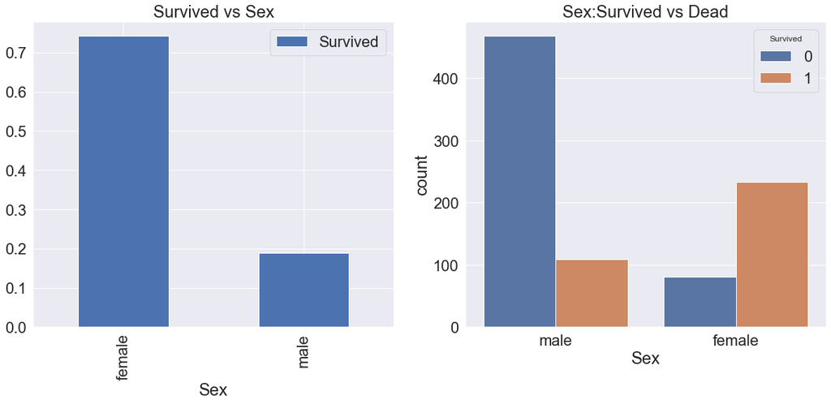

```python
f,ax = plt.subplots(1,2,figsize=(18,8))
df[['Sex','Survived']].groupby(['Sex']).mean().plot.bar(ax=ax[0])
ax[0].set_title('Survived vs Sex')
sns.countplot('Sex',hue='Survived',data=df,ax=ax[1])
ax[1].set_title('Sex:Survived vs Dead')
plt.show()
```

we can see from the data that the Gender played a Huge Role in determining who survives and who doesn't as the Female percentage who survived is way higher than the male percentage.

Now we are going to visualize the siblings and spouse role in the survival

```python
df.groupby(['SibSp','Survived'])['Survived'].count()
```

```
SibSp  Survived
0      0           398
       1           210
1      0            97
       1           112
2      0            15
       1            13
3      0            12
       1             4
4      0            15
       1             3
5      0             5
8      0             7
Name: Survived, dtype: int64
```

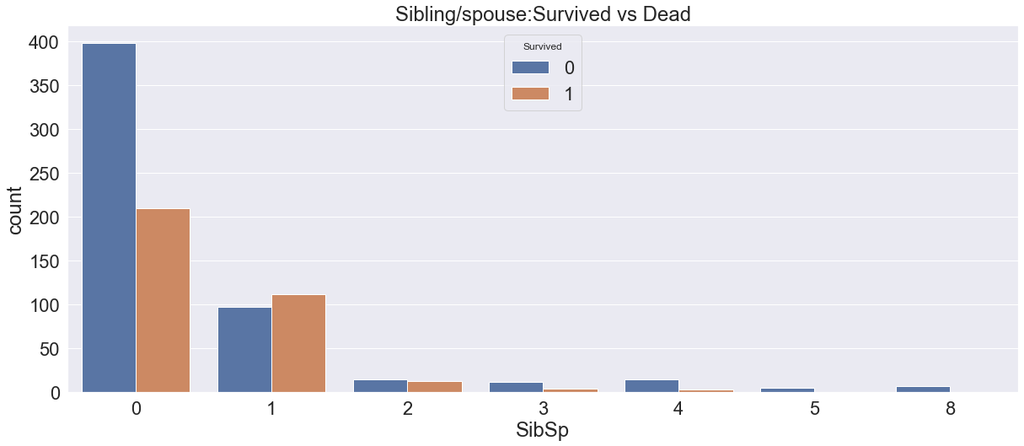

```python
f,ax = plt.subplots(figsize=(18,8))
sns.countplot('SibSp',hue='Survived',data=df,ax=ax)
ax.set_title('Sibling/spouse:Survived vs Dead')
plt.show()
```

The Plot shows that the majority of people who Survived either had no spouse/Sibling or had one to two however as the number increases the probability decreases

Now we are going to visualize the Parent and Children role in the survival

```python
df.groupby(['Parch','Survived'])['Survived'].count()
```

```
Parch  Survived
0      0           445
       1           233
1      0            53
       1            65
2      0            40
       1            40
3      0             2
       1             3
4      0             4
5      0             4
       1             1
6      0             1
Name: Survived, dtype: int64
```

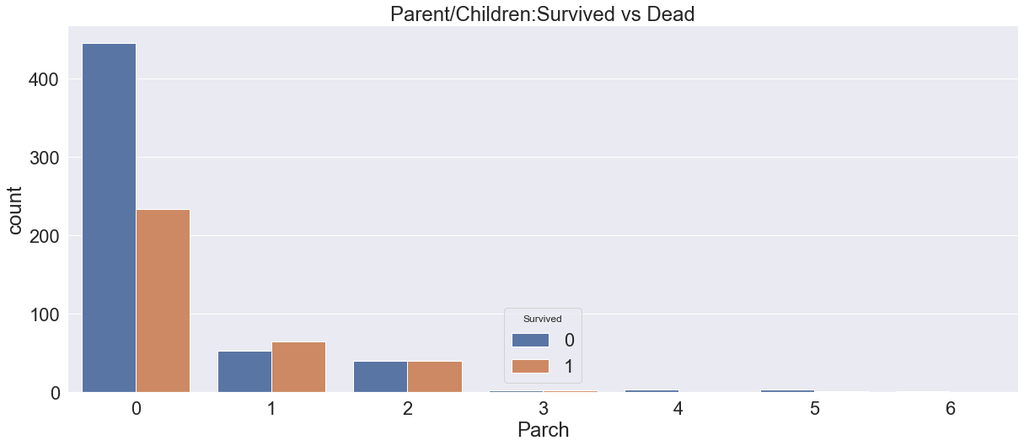

```python
f,ax = plt.subplots(figsize=(18,8))
sns.countplot('Parch',hue='Survived',data=df,ax=ax)
ax.set_title('Parent/Children:Survived vs Dead')
plt.show()
```

The Data Suggests that as the number of Parent increase the Survival Rate increase till it reaches 3, Which makes sense as people with family where first in the queue to survival till they reach a huge amount then they lose their chnace either for capacity reasons or couldnt find the rest of the family and refused to take rescue boats without them

Now we are gonna explore the role of P class in determining the Survival rate and see if there is a trend

```python
df.groupby(['Pclass','Survived'])['Survived'].count()
```

```
Pclass  Survived
1       0            80
        1           136
2       0            97
        1            87
3       0           372
        1           119
Name: Survived, dtype: int64
```

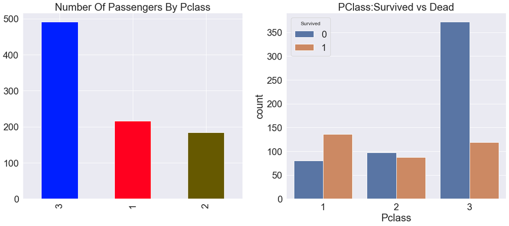

```python
f,ax = plt.subplots(1,2,figsize=(18,8))
df['Pclass'].value_counts().plot.bar(color=['#001fff','#ff001f','#665900'],ax=ax[0])
ax[0].set_title('Number Of Passengers By Pclass')

sns.countplot('Pclass',hue='Survived',data=df,ax=ax[1])
ax[1].set_title('PClass:Survived vs Dead')
plt.show()
```

The Data Suggests that the People in Pclass 1 had the highest Suvival Rate This might be for two reason, either the they got special Treatment or based on their class they were seated next to the boats and it might be correlated with other factors for example the people in the low PClass had high values for Parch or SibSp

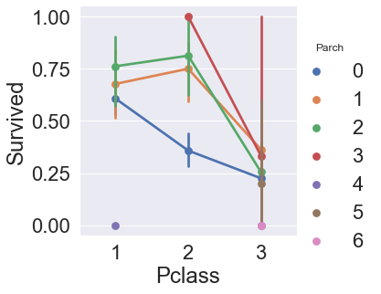

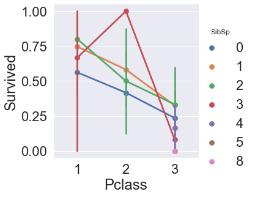

```python
sns.factorplot('Pclass','Survived',hue='Parch',data=df)
sns.factorplot('Pclass','Survived',hue='SibSp',data=df)
plt.show()
```

Since Age is not a Discrete value and is continous so the way we are going to present it is different from the rest of the data

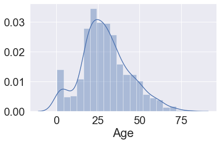

```python
sns.distplot(df['Age'])
```

```python
df['Age'].mean()
```

```
29.69911764705882
```

As both the Age distribution and mean of Age show that passengers on the Titanic where in there late 20's, now we have to show a distribution that corrlates age to survival

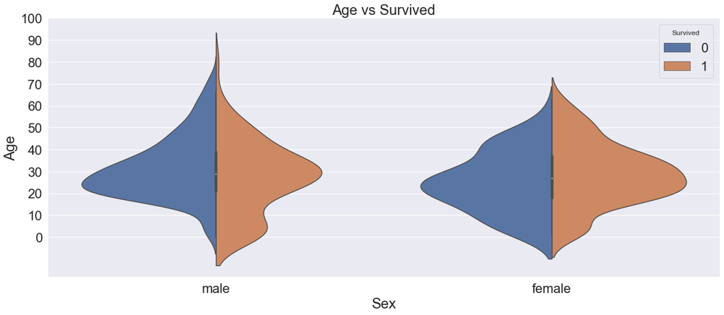

```python
f, ax = plt.subplots(figsize=(18,8))
sns.violinplot('Sex','Age',hue='Survived',data=df,split=True,ax=ax)
ax.set_title('Age vs Survived')
ax.set_yticks(range(0,110,10))
plt.show()
```

Now we have to fill the Null Values in Age to get more accurate data presentation and we are going to categorize the data based initials before each name

```python
df['initial']=0
for i in df:
    df['initial']=df.Name.str.extract('([A-Za-z]+)\.')
pd.crosstab(df.initial,df.Sex).T.style.background_gradient(cmap='summer')
```

| initial Sex | Capt | Col | Countess | Don | Dr | Jonkheer | Lady | Major | Master | Miss | Mlle | Mme | Mr | Mrs | Ms | Rev | Sir |
| --- | --- | --- | --- | --- | --- | --- | --- | --- | --- | --- | --- | --- | --- | --- | --- | --- | --- |
| female | 0 | 0 | 1 | 0 | 1 | 0 | 1 | 0 | 0 | 182 | 2 | 1 | 0 | 125 | 1 | 0 | 0 |
| male | 1 | 2 | 0 | 1 | 6 | 1 | 0 | 2 | 40 | 0 | 0 | 0 | 517 | 0 | 0 | 6 | 1 |

Now Replacing some of the initials that are similar with one common value to assign age easier to each category

```python
df['initial'].replace(['Mlle','Mme','Ms','Dr','Major','Lady','Countess','Jonkheer','Col','Rev','Capt','Sir','Don'],['Miss','Miss','Miss','Mr','Mr','Mrs','Mrs','Other','Other','Other','Mr','Mr','Mr'],inplace=True)
```

```python
df.groupby('initial')['Age'].mean()
```

```
initial
Master     4.574167
Miss      21.860000
Mr        32.739609
Mrs       35.981818
Other     45.888889
Name: Age, dtype: float64
```

now that we have the mean for each category we can assign age for the missing ones

```python
df.loc[(df.Age.isnull())&(df.initial=='Mr'),'Age']=33
df.loc[(df.Age.isnull())&(df.initial=='Mrs'),'Age']=36
df.loc[(df.Age.isnull())&(df.initial=='Master'),'Age']=5
df.loc[(df.Age.isnull())&(df.initial=='Miss'),'Age']=22
df.loc[(df.Age.isnull())&(df.initial=='Other'),'Age']=46
```

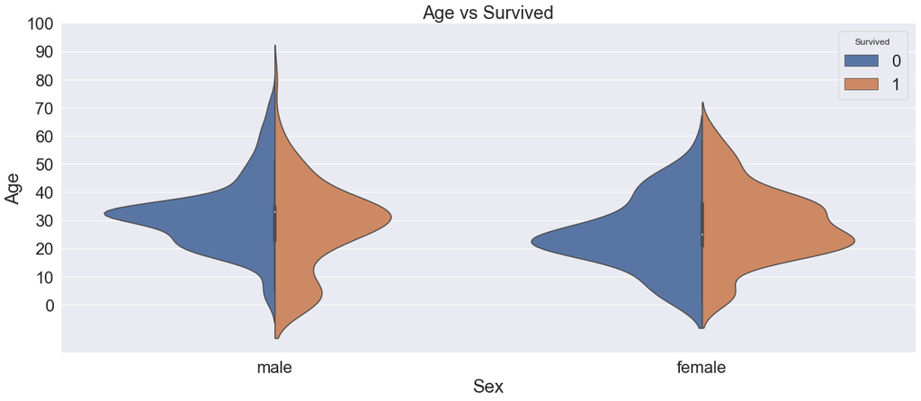

```python
f, ax = plt.subplots(figsize=(18,8))
sns.violinplot('Sex','Age',hue='Survived',data=df,split=True,ax=ax)
ax.set_title('Age vs Survived')
ax.set_yticks(range(0,110,10))
plt.show()
```

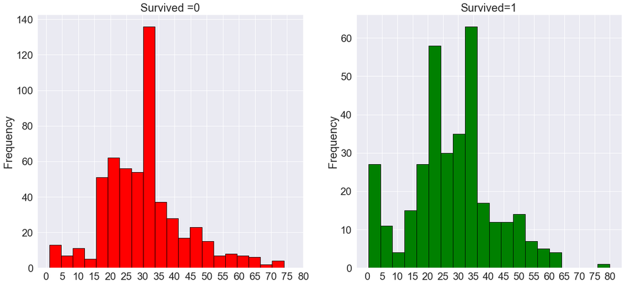

```python
f,ax =plt.subplots(1,2,figsize=(20,10))
df[df['Survived']==0].Age.plot.hist(ax=ax[0],bins=20,edgecolor='black',color='red')
ax[0].set_title('Survived =0')
x1=list(range(0,85,5))
ax[0].set_xticks(x1)
df[df['Survived']==1].Age.plot.hist(ax=ax[1],color='green',bins=20,edgecolor='black')
ax[1].set_title('Survived=1')
x2=list(range(0,85,5))
ax[1].set_xticks(x2)
plt.show()
```

We can notice that the age where the survivors where the most compared to non survivors is 0 to 15

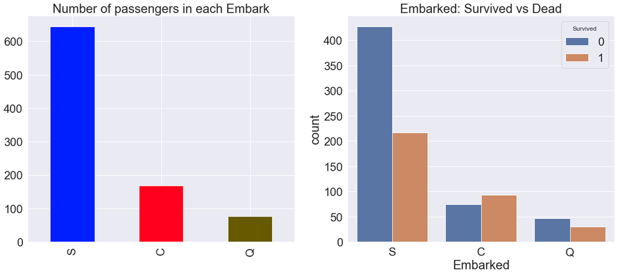

```python
f,ax = plt.subplots(1,2,figsize=(18,8))
df['Embarked'].value_counts().plot.bar(color=['#001fff','#ff001f','#665900'],ax=ax[0])
ax[0].set_title('Number of passengers in each Embark')

sns.countplot('Embarked',hue='Survived',data=df,ax=ax[1])
ax[1].set_title('Embarked: Survived vs Dead')
plt.show()
```

since the majority of Embarked is in S we are going to fill the null values with S

```python
df.loc[(df.Embarked.isnull()),'Embarked']='S'
df.Embarked.isnull().any()#it gave False which proves that there is no null values anymore
```

```
False
```

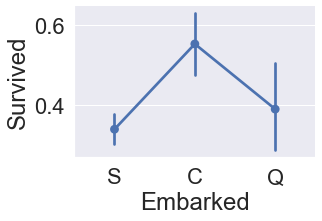

```python
sns.factorplot('Embarked','Survived',data=df)
fig = plt.gcf()
fig.set_size_inches(5,3)
plt.show()
```

The Chances for Survival at port C is tghe highest among all other ports

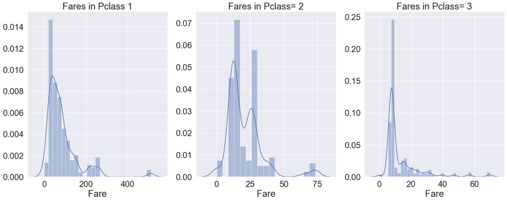

```python
f, ax = plt.subplots(1,3,figsize=(20,8))
sns.distplot(df[df['Pclass']==1].Fare,ax=ax[0])
ax[0].set_title('Fares in Pclass 1')
sns.distplot(df[df['Pclass']==2].Fare,ax=ax[1])
ax[1].set_title('Fares in Pclass= 2')
sns.distplot(df[df['Pclass']==3].Fare,ax=ax[2])
ax[2].set_title('Fares in Pclass= 3')
```

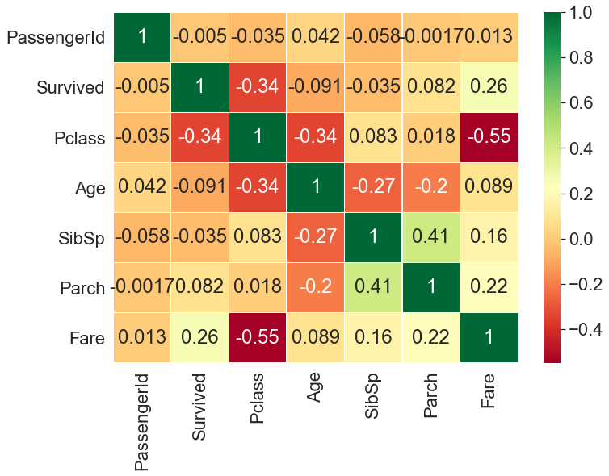

```python
cor = df.corr()
sns.heatmap(cor,annot=True,cmap='RdYlGn',linewidths=0.2)
fig = plt.gcf()
fig.set_size_inches(10,8)
plt.show()
```

We can see that the highest correlation is between Parch and SibSp which makes sense and the highest negative correlation is between the Fare price and the Pclass which makes sense too

Cabin is a feature with a lot of NAN values that we can't fill so we are going to drop it from our dataset

```python
df['Fare_Range']=pd.qcut(df['Fare'],4)
df.groupby(['Fare_Range'])['Survived'].mean().to_frame().style.background_gradient(cmap='summer_r')
```

| Fare_Range | Survived |
| --- | --- |
| (-0.001, 7.91] | 0.197309 |
| (7.91, 14.454] | 0.303571 |
| (14.454, 31.0] | 0.454955 |
| (31.0, 512.329] | 0.581081 |

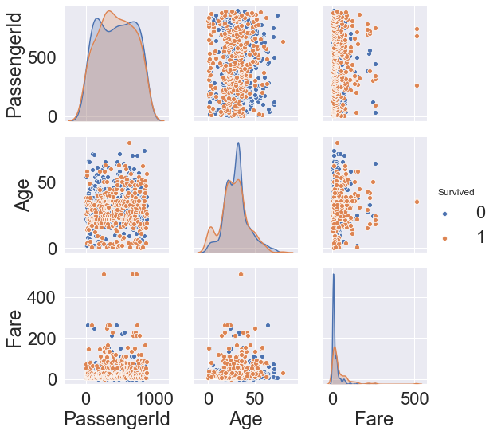

```python
numeric = df.iloc[: , [0,1,5,9]]
sns.pairplot(numeric.dropna(), hue='Survived')
```

Now after analysing all data what is left is to find a range for both age and fare where we categorize them in three to four categories then we are ready to run one of our machine learning algorithm training it on this data set and testing it on the test data set

```python
df['Age_band']=0
df.loc[df['Age']<=16,'Age_band']=0
df.loc[(df['Age']>16)&(df['Age']<=32),'Age_band']=1
df.loc[(df['Age']>32)&(df['Age']<=48),'Age_band']=2
df.loc[(df['Age']>48)&(df['Age']<=64),'Age_band']=3
df.loc[(df['Age']>64),'Age_band']=4
df['Age_band'].value_counts()
```

```
1    382
2    325
0    104
3     69
4     11
Name: Age_band, dtype: int64
```

```python
df['Sex'].replace(['male','female'],[0,1],inplace=True)
df['Embarked'].replace(['S','C','Q'],[0,1,2],inplace=True)
df['initial'].replace(['Mr','Mrs','Miss','Master','Other'],[0,1,2,3,4],inplace=True)
```

```python
df
```

|  | PassengerId | Survived | Pclass | Name | Sex | Age | SibSp | Parch | Ticket | Fare | Cabin | Embarked | initial | Fare_Range | Age_band |
| --- | --- | --- | --- | --- | --- | --- | --- | --- | --- | --- | --- | --- | --- | --- | --- |
| 0 | 1 | 0 | 3 | Braund, Mr. Owen Harris | 0 | 22.0 | 1 | 0 | A/5 21171 | 7.2500 | NaN | 0 | 0 | (-0.001, 7.91] | 1 |
| 1 | 2 | 1 | 1 | Cumings, Mrs. John Bradley (Florence Briggs Th... | 1 | 38.0 | 1 | 0 | PC 17599 | 71.2833 | C85 | 1 | 1 | (31.0, 512.329] | 2 |
| 2 | 3 | 1 | 3 | Heikkinen, Miss. Laina | 1 | 26.0 | 0 | 0 | STON/O2. 3101282 | 7.9250 | NaN | 0 | 2 | (7.91, 14.454] | 1 |
| 3 | 4 | 1 | 1 | Futrelle, Mrs. Jacques Heath (Lily May Peel) | 1 | 35.0 | 1 | 0 | 113803 | 53.1000 | C123 | 0 | 1 | (31.0, 512.329] | 2 |
| 4 | 5 | 0 | 3 | Allen, Mr. William Henry | 0 | 35.0 | 0 | 0 | 373450 | 8.0500 | NaN | 0 | 0 | (7.91, 14.454] | 2 |
| ... | ... | ... | ... | ... | ... | ... | ... | ... | ... | ... | ... | ... | ... | ... | ... |
| 886 | 887 | 0 | 2 | Montvila, Rev. Juozas | 0 | 27.0 | 0 | 0 | 211536 | 13.0000 | NaN | 0 | 4 | (7.91, 14.454] | 1 |
| 887 | 888 | 1 | 1 | Graham, Miss. Margaret Edith | 1 | 19.0 | 0 | 0 | 112053 | 30.0000 | B42 | 0 | 2 | (14.454, 31.0] | 1 |
| 888 | 889 | 0 | 3 | Johnston, Miss. Catherine Helen "Carrie" | 1 | 22.0 | 1 | 2 | W./C. 6607 | 23.4500 | NaN | 0 | 2 | (14.454, 31.0] | 1 |
| 889 | 890 | 1 | 1 | Behr, Mr. Karl Howell | 0 | 26.0 | 0 | 0 | 111369 | 30.0000 | C148 | 1 | 0 | (14.454, 31.0] | 1 |
| 890 | 891 | 0 | 3 | Dooley, Mr. Patrick | 0 | 32.0 | 0 | 0 | 370376 | 7.7500 | NaN | 2 | 0 | (-0.001, 7.91] | 1 |

891 rows × 15 columns

```python
y = df.Survived
```

```python
titanic_features=['Pclass','Sex','Age_band','Embarked','initial','SibSp','Fare','Parch']
```

```python
X = df[titanic_features]
```

```python
df1=pd.read_csv('test.csv')
```

```python
df1.isnull().sum()
```

```
PassengerId      0
Pclass           0
Name             0
Sex              0
Age             86
SibSp            0
Parch            0
Ticket           0
Fare             1
Cabin          327
Embarked         0
dtype: int64
```

```python
df1['initial']=0
for i in df1:
    df1['initial']=df.Name.str.extract('([A-Za-z]+)\.')
pd.crosstab(df.initial,df1.Sex).T.style.background_gradient(cmap='summer')
```

| initial Sex | 0 | 1 | 2 | 3 | 4 |
| --- | --- | --- | --- | --- | --- |
| female | 83 | 21 | 37 | 9 | 2 |
| male | 149 | 37 | 65 | 14 | 1 |

```python
df1['initial'].replace(['Mlle','Mme','Ms','Dr','Major','Lady','Countess','Jonkheer','Col','Rev','Capt','Sir','Don'],['Miss','Miss','Miss','Mr','Mr','Mrs','Mrs','Other','Other','Other','Mr','Mr','Mr'],inplace=True)
```

```python
df1.groupby('initial')['Age'].mean()
```

```
initial
Master    30.476190
Miss      32.135802
Mr        29.826906
Mrs       28.847447
Other     26.500000
Name: Age, dtype: float64
```

```python
df1.loc[(df1.Age.isnull())&(df1.initial=='Mr'),'Age']=33
df1.loc[(df1.Age.isnull())&(df1.initial=='Mrs'),'Age']=36
df1.loc[(df1.Age.isnull())&(df1.initial=='Master'),'Age']=5
df1.loc[(df1.Age.isnull())&(df1.initial=='Miss'),'Age']=22
df1.loc[(df1.Age.isnull())&(df1.initial=='Other'),'Age']=46
```

```python
df1.loc[(df1.Embarked.isnull()),'Embarked']='S'
df1.Embarked.isnull().any()#it gave False which proves that there is no null values anymore
```

```
False
```

```python
df1.loc[(df1.Fare.isnull()),'Fare']=df1.Fare.mean()
```

```python
df1.isnull().sum()
```

```
PassengerId      0
Pclass           0
Name             0
Sex              0
Age              0
SibSp            0
Parch            0
Ticket           0
Fare             0
Cabin          327
Embarked         0
initial          0
dtype: int64
```

```python
df1['Sex'].replace(['male','female'],[0,1],inplace=True)
df1['Embarked'].replace(['S','C','Q'],[0,1,2],inplace=True)
df1['initial'].replace(['Mr','Mrs','Miss','Master','Other'],[0,1,2,3,4],inplace=True)
```

```python
df1['Age_band']=0
df1.loc[df['Age']<=16,'Age_band']=0
df1.loc[(df['Age']>16)&(df['Age']<=32),'Age_band']=1
df1.loc[(df['Age']>32)&(df['Age']<=48),'Age_band']=2
df1.loc[(df['Age']>48)&(df['Age']<=64),'Age_band']=3
df1.loc[(df['Age']>64),'Age_band']=4
df1['Age_band'].value_counts()
df1
```

|  | PassengerId | Pclass | Name | Sex | Age | SibSp | Parch | Ticket | Fare | Cabin | Embarked | initial | Age_band |
| --- | --- | --- | --- | --- | --- | --- | --- | --- | --- | --- | --- | --- | --- |
| 0 | 892 | 3 | Kelly, Mr. James | 0 | 34.5 | 0 | 0 | 330911 | 7.8292 | NaN | 2 | 0 | 1 |
| 1 | 893 | 3 | Wilkes, Mrs. James (Ellen Needs) | 1 | 47.0 | 1 | 0 | 363272 | 7.0000 | NaN | 0 | 1 | 2 |
| 2 | 894 | 2 | Myles, Mr. Thomas Francis | 0 | 62.0 | 0 | 0 | 240276 | 9.6875 | NaN | 2 | 2 | 1 |
| 3 | 895 | 3 | Wirz, Mr. Albert | 0 | 27.0 | 0 | 0 | 315154 | 8.6625 | NaN | 0 | 1 | 2 |
| 4 | 896 | 3 | Hirvonen, Mrs. Alexander (Helga E Lindqvist) | 1 | 22.0 | 1 | 1 | 3101298 | 12.2875 | NaN | 0 | 0 | 2 |
| ... | ... | ... | ... | ... | ... | ... | ... | ... | ... | ... | ... | ... | ... |
| 413 | 1305 | 3 | Spector, Mr. Woolf | 0 | 33.0 | 0 | 0 | A.5. 3236 | 8.0500 | NaN | 0 | 0 | 2 |
| 414 | 1306 | 1 | Oliva y Ocana, Dona. Fermina | 1 | 39.0 | 0 | 0 | PC 17758 | 108.9000 | C105 | 1 | 0 | 2 |
| 415 | 1307 | 3 | Saether, Mr. Simon Sivertsen | 0 | 38.5 | 0 | 0 | SOTON/O.Q. 3101262 | 7.2500 | NaN | 0 | 1 | 2 |
| 416 | 1308 | 3 | Ware, Mr. Frederick | 0 | 36.0 | 0 | 0 | 359309 | 8.0500 | NaN | 0 | 1 | 2 |
| 417 | 1309 | 3 | Peter, Master. Michael J | 0 | 22.0 | 1 | 1 | 2668 | 22.3583 | NaN | 1 | 2 | 1 |

418 rows × 13 columns

```python
df2=pd.read_csv('gender_submission.csv')
Y=df2['Survived']
Y
```

```
0      0
1      1
2      0
3      0
4      1
      ..
413    0
414    1
415    0
416    0
417    0
Name: Survived, Length: 418, dtype: int64
```

```python
titanic_features_test=['Pclass','Sex','Age_band','Embarked','initial','SibSp','Fare','Parch']
```

```python
X1 = df1[titanic_features_test]
X1
```

|  | Pclass | Sex | Age_band | Embarked | initial | SibSp | Fare | Parch |
| --- | --- | --- | --- | --- | --- | --- | --- | --- |
| 0 | 3 | 0 | 1 | 2 | 0 | 0 | 7.8292 | 0 |
| 1 | 3 | 1 | 2 | 0 | 1 | 1 | 7.0000 | 0 |
| 2 | 2 | 0 | 1 | 2 | 2 | 0 | 9.6875 | 0 |
| 3 | 3 | 0 | 2 | 0 | 1 | 0 | 8.6625 | 0 |
| 4 | 3 | 1 | 2 | 0 | 0 | 1 | 12.2875 | 1 |
| ... | ... | ... | ... | ... | ... | ... | ... | ... |
| 413 | 3 | 0 | 2 | 0 | 0 | 0 | 8.0500 | 0 |
| 414 | 1 | 1 | 2 | 1 | 0 | 0 | 108.9000 | 0 |
| 415 | 3 | 0 | 2 | 0 | 1 | 0 | 7.2500 | 0 |
| 416 | 3 | 0 | 2 | 0 | 1 | 0 | 8.0500 | 0 |
| 417 | 3 | 0 | 1 | 1 | 2 | 1 | 22.3583 | 1 |

418 rows × 8 columns

```python
from sklearn.tree import DecisionTreeRegressor
Ti_model = DecisionTreeRegressor(random_state=1)
# Fit the model
Ti_model.fit(X, y)
```

```
DecisionTreeRegressor(random_state=1)
```

```python
from sklearn.metrics import mean_squared_error
predicted_Survivor = Ti_model.predict(X1)
mean_squared_error(Y, predicted_Survivor)
```

```
0.41490282484003066
```

```python
n_splits = 10
shuffle=False
cv = KFold(n_splits=n_splits, shuffle = shuffle)
```

```python
from sklearn.neighbors import KNeighborsClassifier
scores = []

model = KNeighborsClassifier(n_neighbors=50)
for train_index, test_index in cv.split(X):
    #Create the Training and Test
    print("\n____________________________")
    #print(f"Train Index: {train_index}\n")
    print(f"Test Index: {test_index}\n")
    model.fit(X, y)

    #Cross-Validation Prediction Error
    score = model.score(X1, Y)
    print("Score:", score)
    scores.append(score)
```

[output not shown]

[output cut: 33 more lines]

```
 731 732 733 734 735 736 737 738 739 740 741 742 743 744 745 746 747 748
 749 750 751 752 753 754 755 756 757 758 759 760 761 762 763 764 765 766
 767 768 769 770 771 772 773 774 775 776 777 778 779 780 781 782 783 784
 785 786 787 788 789 790 791 792 793 794 795 796 797 798 799 800 801]

Score: 0.6196172248803827

____________________________
Test Index: [802 803 804 805 806 807 808 809 810 811 812 813 814 815 816 817 818 819
 820 821 822 823 824 825 826 827 828 829 830 831 832 833 834 835 836 837
 838 839 840 841 842 843 844 845 846 847 848 849 850 851 852 853 854 855
 856 857 858 859 860 861 862 863 864 865 866 867 868 869 870 871 872 873
 874 875 876 877 878 879 880 881 882 883 884 885 886 887 888 889 890]

Score: 0.6196172248803827
```

```python
print('Accuracy: %.3f (%.3f)' % (np.mean(scores), np.std(scores)))
```

```
Accuracy: 0.620 (0.000)
```

```
Accuracy: 0.620
```

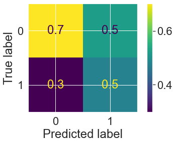

```python
score_OOS = model.score(X1, Y)
print('Accuracy: %.3f' % (score_OOS))
plot_confusion_matrix(model, X1, Y, values_format= '.0', normalize='pred')
plt.show()
```

We can see that the KNN model gave an accuracy of 0.62 which implies that the model is right more than half of the time which is pretty descent knowing that our variables dont have all the factors and contain some noise

Improvements we can improve our model by running a LASSO Regression on our variables to determine which one are important for our prediction and which are not to filter noise and better prediction. The output of the LASSO Regression could be the input of another calssification algorithm.